# 13-2-2 QA

Emma Wood

29/06/2022

**Run date and time: 2022-07-01 09:34:57**

## Introduction

13-2-2 is a very straightforward indicator and automation isn’t particularly necessary, however it will speed up the addition of extra disaggregations if that is wanted.

This file runs some basic checks and gives information about the update.

Before putting the csv in the indicator file please check if the most recent figures are provisional. Check this in the source data. If they are, in the indicator csv file change the observation status to ‘Provisional’.

## Configurations

The configurations for this run are:

- filepath for input data: **D:/coding_repos/sdg_data_updates/13-2-2/Example_Input/example_final-greenhouse-gas-emissions-tables.xlsx**
- name of the tab the data are in: **1.1**
- row number of the column names: **6**
- location of outputs: **D:/coding_repos/sdg_data_updates/13-2-2/Example_Output**

## Basic checks

The dates listed in the information above 1.1, should match the dates produced in the output csv. It is FALSE that the earliest date in the dataset matches the earliest date given above the table. It is TRUE that the latest date in the dataset matches the latest date given above the table. If either of these are ‘FALSE’ please manually check that the numbers in the output csv match those in Example_Input/example_final-greenhouse-gas-emissions-tables.xlsx.

The geography listed in the information at the top of example_final-greenhouse-gas-emissions-tables.xlsx, table 1.1 is UK, United Kingdom. Please check that this matches the geography given in the indicator file metadata.

## Plots

Please check the plots below for any differences between the live and new data. Live data will appear over the top of new data, so if you don’t see points for the new data on dates where there is also live data this is a good thing.

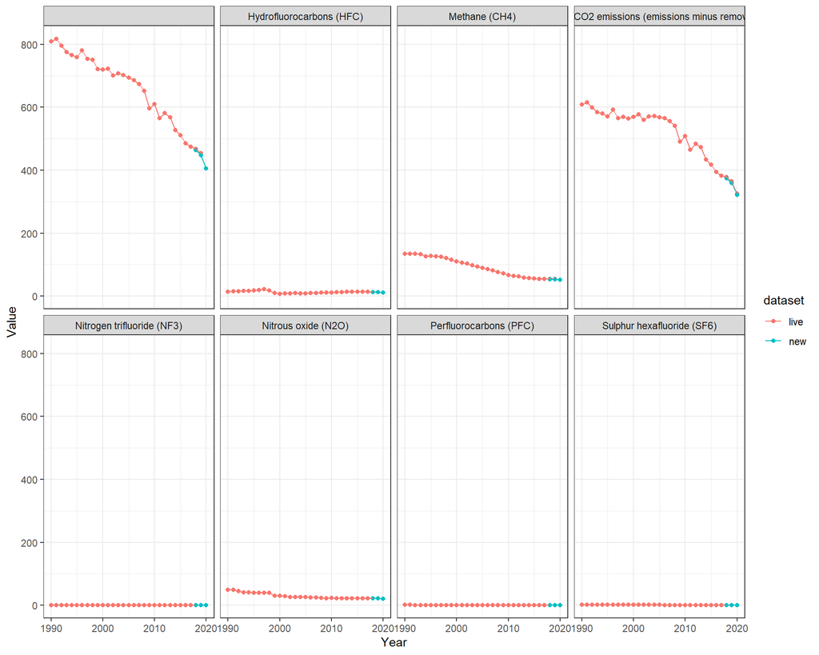

At the time of writing this code (June 2022), the following note is given in the source notes tab: ’ in these statistics the entire time series going back to 1990 is revised each year to take account of methodological improvements.’.

**If there are differences (see table below) please check that this still stands**

The table below shows all instances where the old value does not match the new value. It is sorted so the largest absolute differences appear first, but can be sorted in other ways using the arrows at the top.

| Year | Gas | live | new | difference |
| --- | --- | --- | --- | --- |
| 2019 |  | 454.766072621302 | 447.87743622163 | -6.88863639967241 |
| 2019 | Net CO2 emissions (emissions minus removals) | 365.079723552922 | 359.324677772558 | -5.75504578036436 |
| 2020 | Net CO2 emissions (emissions minus removals) | 326.129188 | 321.087656184015 | -5.04153181598508 |
| 2018 |  | 468.0556469089 | 463.463235225119 | -4.59241168378105 |
| 2018 | Net CO2 emissions (emissions minus removals) | 377.707669558618 | 374.024093513544 | -3.68357604507452 |
| 2018 | Methane (CH4) | 54.2880270060805 | 53.6166054984211 | -0.671421507659389 |
| 2019 | Methane (CH4) | 54.0155990576212 | 53.3551237166895 | -0.660475340931711 |
| 2019 | Nitrous oxide (N2O) | 22.2360063129019 | 22.008597891644 | -0.227408421257945 |
| 2019 | Perfluorocarbons (PFC) | 0.344685908542492 | 0.210717666540684 | -0.133968242001808 |
| 2019 | Sulphur hexafluoride (SF6) | 0.58938872690124 | 0.474497663914477 | -0.114891062986763 |

[output cut: 7 more lines]